# Problem Description

# Qn1: the customer who bought the most items overall in her lifetime

```python
df.iloc[:-1].nlargest(5,'item_total').iloc[:,-1:]
```

| id user_id | item_total |
| --- | --- |
| user_269335 | 72 |
| user_367872 | 70 |
| user_397623 | 64 |
| user_599172 | 64 |
| user_377284 | 63 |

```python
"""
This is the list of top5 users who bought the most items.
""";
```

# Qn2: for each item, the customer who bought that product the most

```python
df.head(2).append(df.tail(2))
```

| id user_id | sugar | carrots | cereals | shampoo | bagels | eggs | aluminum foil | milk | beef | laundry detergent | shaving cream | lettuce | grapefruit | cheeses | frozen vegetables | tea | paper towels | cherries | spaghetti sauce | dishwashing | canned vegetables | hand soap | pet items | flour | pasta | apples | toilet paper | tortillas | soap | … |
| --- | --- | --- | --- | --- | --- | --- | --- | --- | --- | --- | --- | --- | --- | --- | --- | --- | --- | --- | --- | --- | --- | --- | --- | --- | --- | --- | --- | --- | --- | --- |
| user_47 | 0 | 0 | 0 | 0 | 1 | 0 | 1 | 1 | 0 | 0 | 0 | 1 | 0 | 0 | 0 | 1 | 1 | 1 | 0 | 0 | 1 | 0 | 1 | 0 | 0 | 0 | 0 | 0 | 0 | … |
| user_68 | 0 | 1 | 0 | 0 | 0 | 0 | 0 | 0 | 1 | 0 | 1 | 0 | 0 | 0 | 0 | 1 | 0 | 1 | 0 | 0 | 0 | 0 | 0 | 0 | 0 | 0 | 0 | 0 | 0 | … |
| user_1499974 | 0 | 1 | 1 | 0 | 1 | 0 | 0 | 0 | 0 | 0 | 0 | 0 | 0 | 1 | 0 | 1 | 0 | 1 | 0 | 0 | 0 | 0 | 0 | 0 | 1 | 0 | 0 | 1 | 0 | … |
| user_total | 9119 | 8859 | 2730 | 3270 | 8695 | 5700 | 3281 | 5782 | 8627 | 6000 | 3346 | 14473 | 8951 | 5666 | 5977 | 8723 | 3278 | 9019 | 6449 | 6115 | 6365 | 3356 | 7204 | 2631 | 2731 | 9008 | 3322 | 8782 | 3282 | … |

```python
df.iloc[:-1].T.idxmax(axis=1).to_frame('user').head()
```

| id | user |
| --- | --- |
| sugar | user_31625 |
| carrots | user_618914 |
| cereals | user_367872 |
| shampoo | user_557904 |
| bagels | user_653800 |

```python
df.iloc[:-1].apply(lambda s: pd.Series(
    [s.idxmax(), s.max()],
    index=['max_user','max_count']
    )).T.head()
```

| id | max_user | max_count |
| --- | --- | --- |
| sugar | user_31625 | 4 |
| carrots | user_618914 | 4 |
| cereals | user_367872 | 3 |
| shampoo | user_557904 | 3 |
| bagels | user_653800 | 4 |

```python
# validate the result
df.head(2)
```

| id user_id | sugar | carrots | cereals | shampoo | bagels | eggs | aluminum foil | milk | beef | laundry detergent | shaving cream | lettuce | grapefruit | cheeses | frozen vegetables | tea | paper towels | cherries | spaghetti sauce | dishwashing | canned vegetables | hand soap | pet items | flour | pasta | apples | toilet paper | tortillas | soap | … |
| --- | --- | --- | --- | --- | --- | --- | --- | --- | --- | --- | --- | --- | --- | --- | --- | --- | --- | --- | --- | --- | --- | --- | --- | --- | --- | --- | --- | --- | --- | --- |
| user_47 | 0 | 0 | 0 | 0 | 1 | 0 | 1 | 1 | 0 | 0 | 0 | 1 | 0 | 0 | 0 | 1 | 1 | 1 | 0 | 0 | 1 | 0 | 1 | 0 | 0 | 0 | 0 | 0 | 0 | … |
| user_68 | 0 | 1 | 0 | 0 | 0 | 0 | 0 | 0 | 1 | 0 | 1 | 0 | 0 | 0 | 0 | 1 | 0 | 1 | 0 | 0 | 0 | 0 | 0 | 0 | 0 | 0 | 0 | 0 | 0 | … |

```python
df.loc['user_31625'].to_frame().T # this user has bought 4 sugars in total
```

| id | sugar | carrots | cereals | shampoo | bagels | eggs | aluminum foil | milk | beef | laundry detergent | shaving cream | lettuce | grapefruit | cheeses | frozen vegetables | tea | paper towels | cherries | spaghetti sauce | dishwashing | canned vegetables | hand soap | pet items | flour | pasta | apples | toilet paper | tortillas | soap | … |
| --- | --- | --- | --- | --- | --- | --- | --- | --- | --- | --- | --- | --- | --- | --- | --- | --- | --- | --- | --- | --- | --- | --- | --- | --- | --- | --- | --- | --- | --- | --- |
| user_31625 | 4 | 2 | 0 | 0 | 0 | 0 | 0 | 0 | 0 | 0 | 3 | 5 | 1 | 0 | 2 | 1 | 0 | 2 | 0 | 1 | 1 | 2 | 1 | 1 | 1 | 1 | 0 | 0 | 2 | … |

```python
df[['sugar']].T.filter(regex='user_31625')
```

| user_id id | user_31625 |
| --- | --- |
| sugar | 4 |

# Qn3: Modelling Clustering of Similar Items

> Cluster items based on user co-purchase history. That is, create clusters of products that have the highest probability of being bought together. The goal of this is to replace the old/manually created categories with these new ones. Each item can belong to just one cluster.

```python
from sklearn.preprocessing import normalize
from sklearn.decomposition import PCA
from sklearn.cluster import KMeans
from sklearn.metrics import silhouette_score
```

```python
df.head(2).append(df.tail(2)).iloc[:,-5:]
```

| id user_id | poultry | sandwich bags | butter | soda | item_total |
| --- | --- | --- | --- | --- | --- |
| user_47 | 0 | 0 | 0 | 0 | 13 |
| user_68 | 1 | 0 | 0 | 0 | 8 |
| user_1499974 | 0 | 1 | 1 | 0 | 13 |
| user_total | 8730 | 3343 | 5717 | 8816 | 319995 |

```python
df.shape
```

```
(24886, 49)
```

```python
# remove colmun and index named total
df = df.iloc[:-1,:-1]

print(df.shape)

df.head(2).append(df.tail(2)).iloc[:,-5:]
```

```
(24885, 48)
```

| id user_id | waffles | poultry | sandwich bags | butter | soda |
| --- | --- | --- | --- | --- | --- |
| user_47 | 0 | 0 | 0 | 0 | 0 |
| user_68 | 0 | 1 | 0 | 0 | 0 |
| user_1499817 | 0 | 1 | 0 | 1 | 1 |
| user_1499974 | 1 | 0 | 1 | 1 | 0 |

## similarity matrix

```python
from sklearn.preprocessing import normalize

item_norm = normalize(df,axis=0) # normalize each items (NOT users)
item_sim = item_norm.T.dot(item_norm)

df_item_sim = pd.DataFrame(item_sim,
                       index=df.columns,
                       columns=df.columns)

print(df_item_sim.shape)
df_item_sim.head(2)
```

```
(48, 48)
```

| id | sugar | carrots | cereals | shampoo | bagels | eggs | aluminum foil | milk | beef | laundry detergent | shaving cream | lettuce | grapefruit | cheeses | frozen vegetables | tea | paper towels | cherries | spaghetti sauce | dishwashing | canned vegetables | hand soap | pet items | flour | pasta | apples | toilet paper | tortillas | soap | … |
| --- | --- | --- | --- | --- | --- | --- | --- | --- | --- | --- | --- | --- | --- | --- | --- | --- | --- | --- | --- | --- | --- | --- | --- | --- | --- | --- | --- | --- | --- | --- |
| sugar | 1.000000 | 0.390641 | 0.263889 | 0.260103 | 0.392767 | 0.336052 | 0.258082 | 0.338954 | 0.386424 | 0.338680 | 0.273667 | 0.506895 | 0.391199 | 0.339366 | 0.344111 | 0.397598 | 0.272608 | 0.398554 | 0.351104 | 0.338670 | 0.357550 | 0.270909 | 0.420145 | 0.259259 | 0.264944 | 0.395828 | 0.275207 | 0.403212 | 0.262791 | … |
| carrots | 0.390641 | 1.000000 | 0.232861 | 0.246780 | 0.379568 | 0.323319 | 0.257784 | 0.325523 | 0.386199 | 0.325983 | 0.256384 | 0.527894 | 0.382947 | 0.322191 | 0.335931 | 0.377047 | 0.258435 | 0.384620 | 0.332691 | 0.330508 | 0.343154 | 0.257511 | 0.352597 | 0.236888 | 0.239542 | 0.375208 | 0.261217 | 0.379041 | 0.248531 | … |

## Choose number of clusters K

```python
from sklearn.cluster import KMeans
from sklearn.metrics import silhouette_score
```

```python
kmeans = KMeans()
kmeans
```

```
KMeans(algorithm='auto', copy_x=True, init='k-means++', max_iter=300,
       n_clusters=8, n_init=10, n_jobs=None, precompute_distances='auto',
       random_state=None, tol=0.0001, verbose=0)
```

```python
inertias = []
silhouettes = []

ks = range(2,30)
for k in ks:
    kmeans = KMeans(n_clusters=k,random_state=SEED,
                init='k-means++',n_jobs=-1)
    kmeans.fit(df_item_sim)

    inertias.append(kmeans.inertia_)
    silhouettes.append(silhouette_score(df_item_sim, kmeans.predict(df_item_sim)))
```

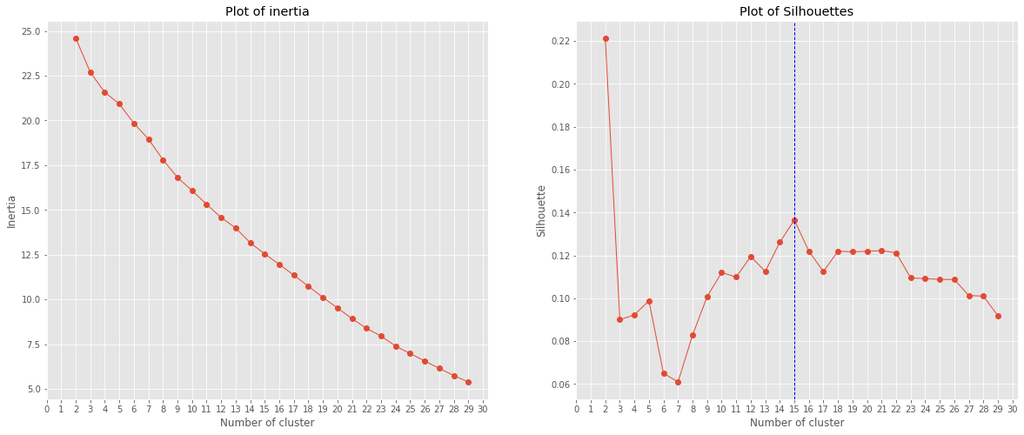

```python
fig, (ax1, ax2) = plt.subplots(1,2,figsize=(20,8))

ax1.plot(ks, inertias,marker='o')
ax1.set_xticks(range(len(ks)+3));
ax1.set_title('Plot of inertia')
ax1.set_xlabel('Number of cluster')
ax1.set_ylabel('Inertia');

# silhoutte plot
ax2.plot(ks,silhouettes,marker='o')
ax2.set_xticks(range(len(ks)+3));
ax2.set_title('Plot of Silhouettes')
ax2.set_xlabel('Number of cluster')
ax2.set_ylabel('Silhouette');

ax2.axvline(15,color='b',ls='--');
```

## Fitting the KMeans model

```python
n_clusters = 15

kmeans = KMeans(n_clusters=n_clusters,random_state=SEED,
                init='k-means++',n_jobs=-1)

kmeans.fit(df_item_sim)
```

```
KMeans(algorithm='auto', copy_x=True, init='k-means++', max_iter=300,
       n_clusters=15, n_init=10, n_jobs=-1, precompute_distances='auto',
       random_state=100, tol=0.0001, verbose=0)
```

```python
kmeans.labels_
```

```
array([ 7,  0, 14,  1, 12,  5,  3,  5, 11,  9,  1,  0,  8,  5, 13,  2,  3,
        8,  6,  9,  6,  1,  7,  4,  4,  8,  3, 12,  1, 13, 12,  2, 12, 10,
        8,  6,  0,  2,  0,  0,  8, 11,  5,  4, 11,  3,  5,  2],
      dtype=int32)
```

## Reduce dimension using PCA and visualize

```python
from sklearn.decomposition import PCA

pca = PCA()
pca
```

```
PCA(copy=True, iterated_power='auto', n_components=None, random_state=None,
    svd_solver='auto', tol=0.0, whiten=False)
```

```python
pca = PCA(n_components=2,random_state=SEED)

arr_pca = pca.fit_transform(df_item_sim)
```

```python
arr_pca.shape
```

```
(48, 2)
```

```python
df_pca = pd.DataFrame(arr_pca, columns=['pc_0', 'pc_1'],
                     index=df_item_sim.index.to_numpy())

df_pca.head(2)
```

|  | pc_0 | pc_1 |
| --- | --- | --- |
| sugar | 0.355639 | -0.025103 |
| carrots | 0.353093 | 0.000351 |

```python
kmeans.labels_
```

```
array([ 7,  0, 14,  1, 12,  5,  3,  5, 11,  9,  1,  0,  8,  5, 13,  2,  3,
        8,  6,  9,  6,  1,  7,  4,  4,  8,  3, 12,  1, 13, 12,  2, 12, 10,
        8,  6,  0,  2,  0,  0,  8, 11,  5,  4, 11,  3,  5,  2],
      dtype=int32)
```

```python
len(kmeans.labels_)
```

```
48
```

```python
colors_dict = dict(enumerate(sns.color_palette('Set2',n_clusters)))
# colors_dict
```

```python
mycolors = [colors_dict[k] for k in kmeans.labels_]

# mycolors
```

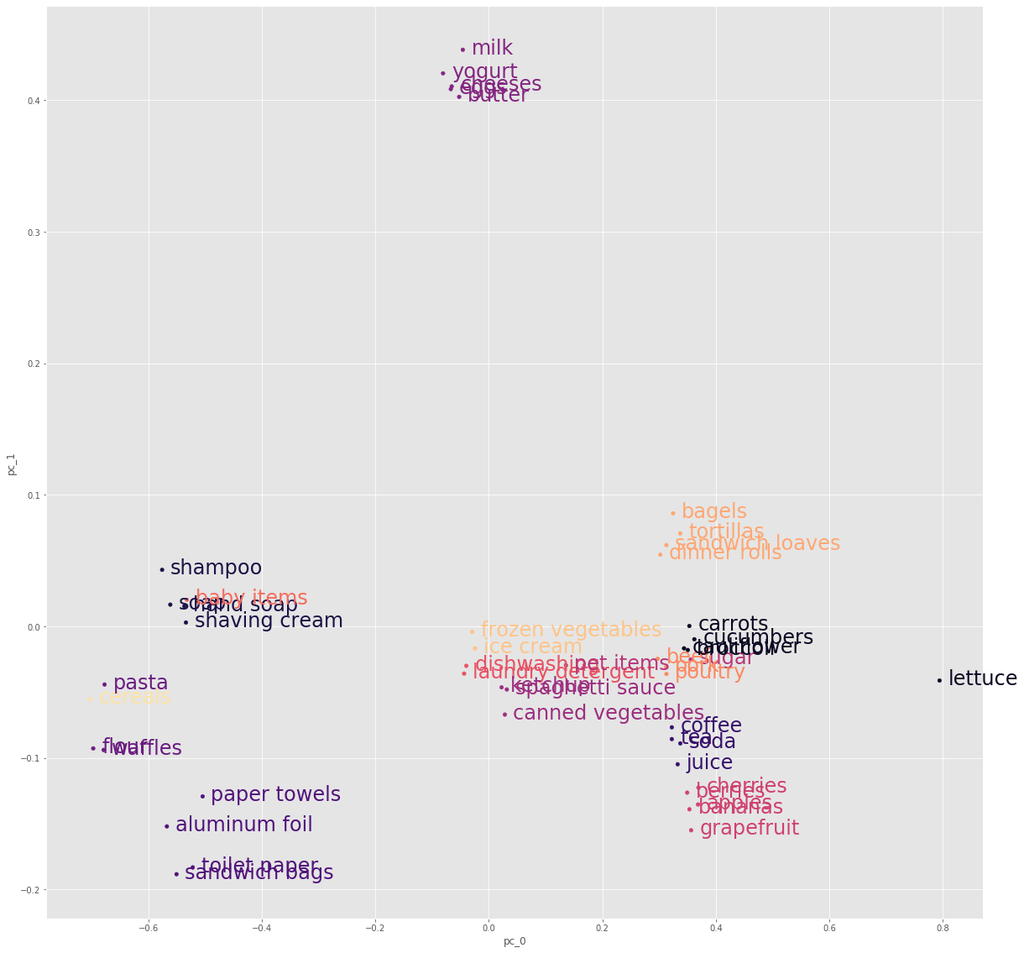

```python
colors_dict = dict(enumerate(sns.color_palette('magma',n_clusters)))
mycolors = [colors_dict[k] for k in kmeans.labels_]

fig, ax = plt.subplots(figsize=(20,20))
df_pca.plot.scatter(x='pc_0',y='pc_1',color=mycolors,ax=ax)

i = 0
for name,(x,y) in df_pca.iloc[:,:2].iterrows():
    ax.annotate(name,[x,y],
                xytext=(10,-5),
                textcoords='offset points',
                size=24,
                color=mycolors[i])
    i+=1
```

## Find the clustered groups

```python
df_item_sim.columns
```

```
Index(['sugar', 'carrots', 'cereals', 'shampoo', 'bagels', 'eggs',
       'aluminum foil', 'milk', 'beef', 'laundry detergent', 'shaving cream',
       'lettuce', 'grapefruit', 'cheeses', 'frozen vegetables', 'tea',
       'paper towels', 'cherries', 'spaghetti sauce', 'dishwashing ',
       'canned vegetables', 'hand soap', 'pet items', 'flour', 'pasta',
       'apples', 'toilet paper', 'tortillas', 'soap', 'ice cream',
       'dinner rolls', 'juice', 'sandwich loaves', 'baby items', 'berries',
       'ketchup', 'cucumbers', 'coffee', 'broccoli', 'cauliflower', 'bananas',
       'pork', 'yogurt', 'waffles', 'poultry', 'sandwich bags', 'butter',
       'soda'],
      dtype='object', name='id')
```

```python
kmeans.labels_
```

```
array([ 7,  0, 14,  1, 12,  5,  3,  5, 11,  9,  1,  0,  8,  5, 13,  2,  3,
        8,  6,  9,  6,  1,  7,  4,  4,  8,  3, 12,  1, 13, 12,  2, 12, 10,
        8,  6,  0,  2,  0,  0,  8, 11,  5,  4, 11,  3,  5,  2],
      dtype=int32)
```

```python
df_labels = pd.DataFrame({
    'item': df_item_sim.columns.to_numpy(),
    'label': kmeans.labels_
})


df_labels.head(2)
```

|  | item | label |
| --- | --- | --- |
| 0 | sugar | 7 |
| 1 | carrots | 0 |

```python
pd.set_option('display.max_colwidth', -1)
df_labels.groupby('label')['item'].apply(list).to_frame()
```

| label | item |
| --- | --- |
| 0 | [carrots, lettuce, cucumbers, broccoli, cauliflower] |
| 1 | [shampoo, shaving cream, hand soap, soap] |
| 2 | [tea, juice, coffee, soda] |
| 3 | [aluminum foil, paper towels, toilet paper, sandwich bags] |
| 4 | [flour, pasta, waffles] |
| 5 | [eggs, milk, cheeses, yogurt, butter] |
| 6 | [spaghetti sauce, canned vegetables, ketchup] |
| 7 | [sugar, pet items] |
| 8 | [grapefruit, cherries, apples, berries, bananas] |
| 9 | [laundry detergent, dishwashing ] |
| 10 | [baby items] |
| 11 | [beef, pork, poultry] |
| 12 | [bagels, tortillas, dinner rolls, sandwich loaves] |
| 13 | [frozen vegetables, ice cream] |
| 14 | [cereals] |

# Time taken

```python
time_taken = time.time() - time_start_notebook
h,m = divmod(time_taken,60*60)
print('Time taken to run whole notebook: {:.0f} hr '\
      '{:.0f} min {:.0f} secs'.format(h, *divmod(m,60)))
```

```
Time taken to run whole notebook: 0 hr 13 min 39 secs
```

```python
import subprocess
subprocess.call(['python', '-m', 'nbconvert', '*.ipynb'])
```